# Project memo

This document should contain a detailed account of the data clean up for your data and the design choices you are making for your plots. For instance you will want to document choices you’ve made that were intentional for your graphic, e.g. color you’ve chosen for the plot. Think of this document as a code script someone can follow to reproduce the data cleaning steps and graphics in your handout.

```r
#install.packages("readxl")
library(tidyverse)
library(broom)
library(readxl)
library(janitor)
```

## Data Clean Up Steps for Overall Data

### Step 1: Load all data

```r
family_support_data <- read.csv ("/cloud/project/data/love_support_family.csv")
kids_overweight <- read_csv("/cloud/project/data/kids_overweight.csv")
drinking_vs_family <- read.csv ("/cloud/project/data/drinking_fam_GRADE.csv")
drunk_smoke_meals_data <- read_xlsx("../data/Drunk_High and smoking and family meals data .xlsx")
```

## Plot 1: Overweight kids by age

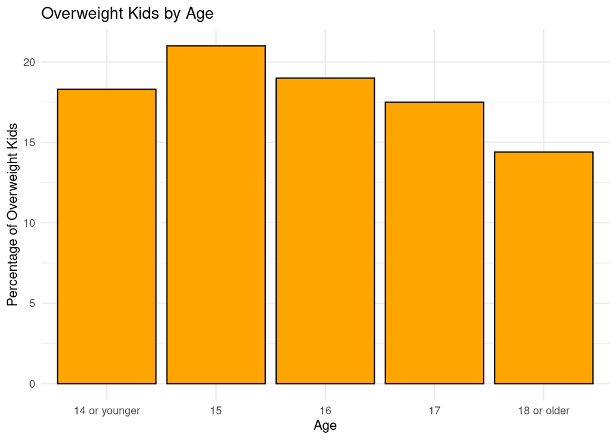

```r
kids_overweight <- kids_overweight |>
  mutate(Age = fct_relevel(Age, "14 or younger", "15", "16", "17"))

# Plot histogram
ggplot(kids_overweight, aes(x = Age, weight = Percentage)) +
  geom_histogram(stat = "count", fill = "orange", color = "black") +
  labs(title = "Overweight Kids by Age",
       x = "Age",
       y = "Percentage of Overweight Kids") +
  theme_minimal()
```

## Plot 1: Overweight kids vs family support by age

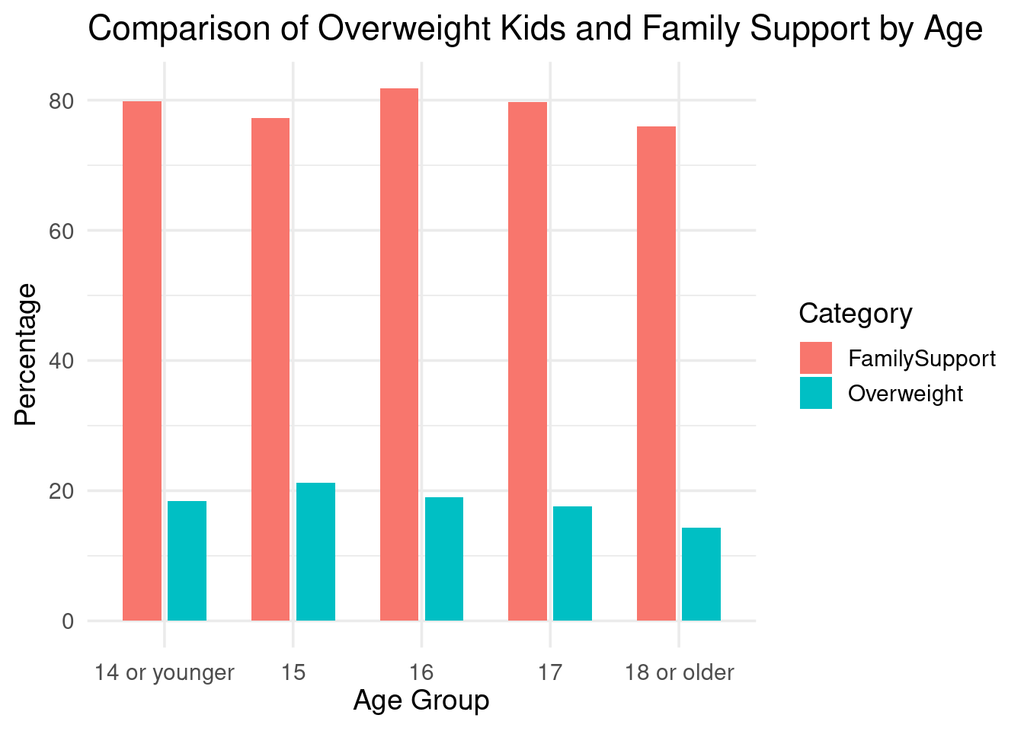

```r
data <- data.frame(
  Age = c("14 or younger", "15", "16", "17", "18 or older"),
  Overweight = c(18.4, 21.2, 19.0, 17.6, 14.3),
  FamilySupport = c(79.80, 77.20, 81.80, 79.70, 76)  # Replace with actual values if available
)

data_long <- data |>
  pivot_longer(cols = c(Overweight, FamilySupport),
               names_to = "Category", values_to = "Percentage")

ggplot(data_long, aes(x = Age, y = Percentage, fill = Category)) +
  geom_bar(stat = "identity", position = position_dodge(width = 0.7), width = 0.6) +
    scale_color_viridis_d() +
  labs(
    title = "Comparison of Overweight Kids and Family Support by Age",
    x = "Age Group",
    y = "Percentage",
    fill = "Category"
  ) +
  theme_minimal(base_size = 14) +
  theme(axis.text.x = element_text(angle = 0, vjust = 0.5))
```

### Plot 3 Cleanup

```r
Drinking_vs_family <- drinking_vs_family |>
  mutate(
    Grade = fct_recode(Grade,
                       NULL = "")
  )

Drinking_data_cleaner <- read.csv("../data/drunk_high_data_2.csv")
```

## Plot 3: Drinking perentage by grade

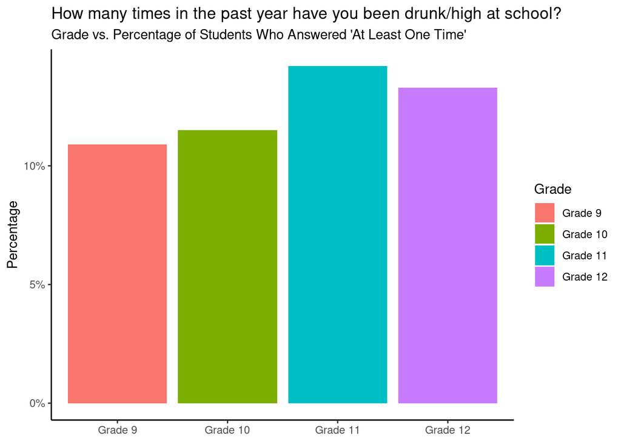

```r
Drinking_vs_family |>
mutate('Grade' = fct_relevel(Grade,
                               "Grade 9",
                               "Grade 10",
                               "Grade 11",
                               "Grade 12"),
         GradePercent = as.numeric(gsub("%", "", GradePercent))) |>
  filter(!is.na(Grade) & !is.na(`GradePercent`)) |>
  ggplot(aes(x = Grade, y = `GradePercent`, fill = Grade)) +
  geom_col(na.rm = TRUE) +
  scale_y_continuous(breaks = seq(0, 20, by = 5),
                     labels = scales::label_percent(scale = 1)) +
  labs(x = NULL,
       y = 'Percentage',
       title = 'How many times in the past year have you been drunk/high at school?',
       subtitle = "Grade vs. Percentage of Students Who Answered 'At Least One Time'")+
  theme_classic()
```

```r
ggsave("../plots/plot-1.jpg", width = 10, height = 4)
```

## Plot 4: Drinking vs. family

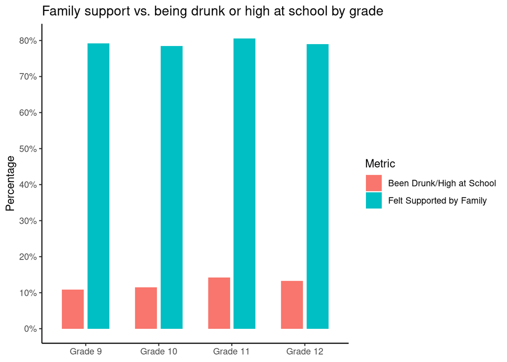

```r
Drinking_vs_family |>
  mutate('Grade' = fct_relevel(Grade,
                               "Grade 9",
                               "Grade 10",
                               "Grade 11",
                               "Grade 12"),
         GradePercent = as.numeric(gsub("%", "", GradePercent)),
         FamGradePer. = as.numeric(gsub("%", "", FamGradePer.))) |>
  filter(!is.na(Grade) & !is.na(`GradePercent`)) |>
  pivot_longer(
    cols = c(GradePercent, FamGradePer.),
    names_to = "Metric",
    values_to = "Percent") |>
  mutate(Metric = recode(Metric,
                       GradePercent = "Been Drunk/High at School",
                       `FamGradePer.` = "Felt Supported by Family")) |>
  ggplot(aes(x = Grade, y = `Percent`, fill = Metric)) +
  geom_bar(stat = "identity", position = position_dodge(width = 0.7), width = 0.6) +
  scale_y_continuous(breaks = seq(0, 100, by = 10),
                     labels = scales::label_percent(scale = 1)) +
  labs(x = NULL,
       y = 'Percentage',
       title = 'Family support vs. being drunk or high at school by grade') +
  theme_classic()
```

```r
ggsave("../plots/plot-2.jpg", width = 10, height = 4)
```

### Plot 5: Drinking count vs. meals vs. gender by age

We chose to include this plot in the memo but not in the final project because while it shows a lot of data relatively concisely, it could cause some confusion because of the number of variables in the graph. Also, it doesn’t reflect female findings and only uses the male data. We did not include alt text for this graph, as it will not be presented anywhere because it’s incomplete and ultimately not useful.

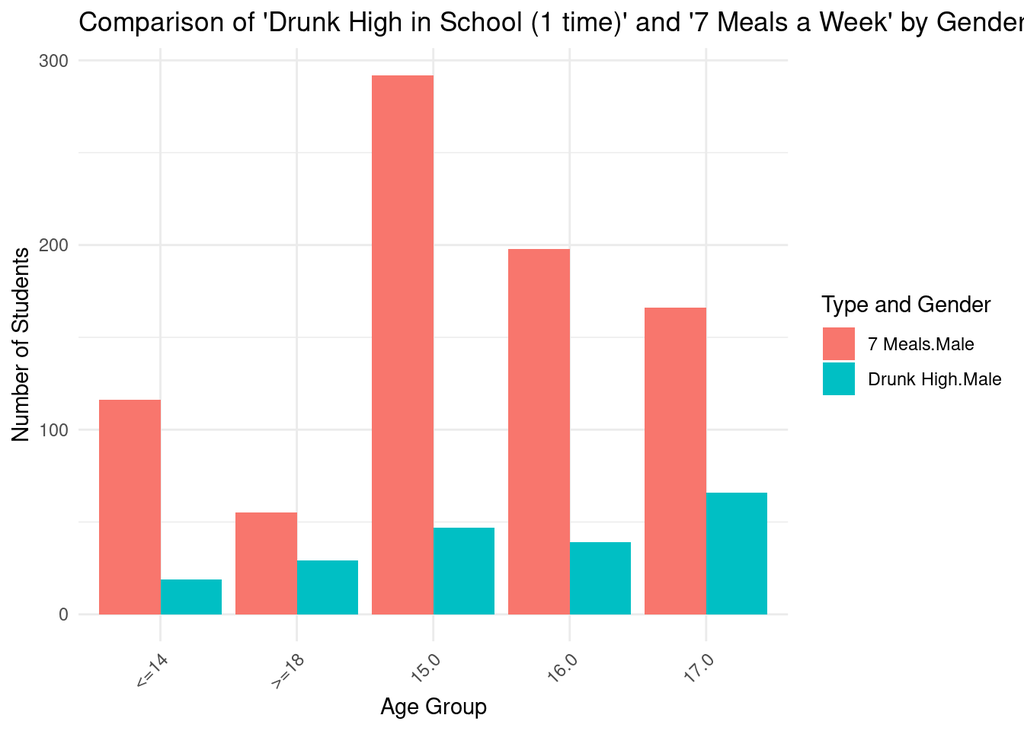

```r
final_data_clean <- drunk_smoke_meals_data |>
  clean_names()

final_data <- final_data_clean |>
  select(age = age_x,
         male_drunk_high = male_drunk_high_in_school_1_time,
         female_drunk_high = female_drunk_high_in_school_1_time,
         male_meals = males_7_meals_a_week,
         female_meals = female_7_meals_a_week) |>
  drop_na() |>
  pivot_longer(cols = -age, names_to = "category", values_to = "count") |>
  mutate(
    type = if_else(str_detect(category, "drunk_high"), "Drunk High", "7 Meals"),
    gender = if_else(str_detect(category, "male"), "Male", "Female")
  )

ggplot(final_data, aes(x = age, y = count, fill = interaction(type, gender))) +
  geom_bar(stat = "identity", position = "dodge") +
  labs(title = "Comparison of 'Drunk High in School (1 time)' and '7 Meals a Week' by Gender",
       x = "Age Group",
       y = "Number of Students",
       fill = "Type and Gender") +
  theme_minimal() +
  theme(axis.text.x = element_text(angle = 45, hjust = 1))
```

```r
ggsave("../plots/plot-5.jpg", width = 10, height = 4)
```

### Plot 6: Drinking vs. gender vs. meals

We chose to include this plot in the memo for the same reason as plot 5. We did not include alt text for this graph, as it also will not be presented anywhere because it’s incomplete and ultimately not useful.

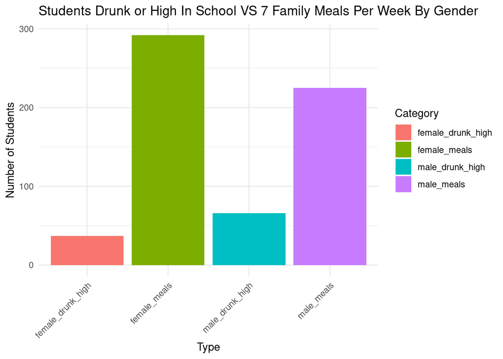

```r
ggplot(final_data, aes(x = category, y = count, fill = category)) +
  geom_bar(stat = "identity", position = "dodge") +
  labs(
    title = "Students Drunk or High In School VS 7 Family Meals Per Week By Gender",
    x = "Type",
    y = "Number of Students",
    fill = "Category"
  ) +
  theme_minimal() +
  theme(axis.text.x = element_text(angle = 45, hjust = 1))
```

```r
ggsave("../plots/plot-6.jpg", width = 10, height = 4)
```

### Plot 7: Smoking vs. meals vs. age faceted by gender

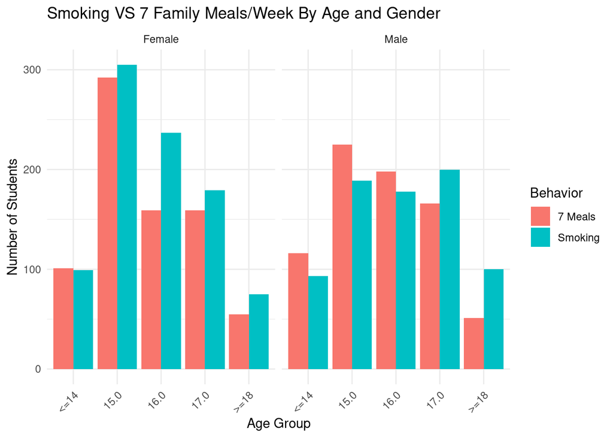

```r
smoke_final <- drunk_smoke_meals_data |>
  select(
    Age = `Age.x`,
    Male_Smoking = `Males 7 days in room atleat 1 cig`,
    Female_Smoking = `Female 7 days in room atleat 1 cig`,
    Male_Meals = `Males 7 meals a week`,
    Female_Meals = `Female 7 meals a week`
  ) |>
  drop_na() |>
  pivot_longer(cols = -Age, names_to = "Category", values_to = "Count") |>
  mutate(
    Gender = case_when(
      str_detect(Category, "Male") ~ "Male",
      str_detect(Category, "Female") ~ "Female"
    ),
    Type = case_when(
      str_detect(Category, "Smoking") ~ "Smoking",
      str_detect(Category, "Meals") ~ "7 Meals"
    ),
    Age = factor(Age, levels = c("<=14", "15.0", "16.0", "17.0", ">=18"))
  )

ggplot(smoke_final, aes(x = Age, y = Count, fill = Type)) +
  geom_bar(stat = "identity", position = "dodge") +
  facet_wrap(~ Gender) +
  labs(
    title = "Smoking VS 7 Family Meals/Week By Age and Gender",
    x = "Age Group",
    y = "Number of Students",
    fill = "Behavior"
  ) +
  theme_minimal() +
  theme(axis.text.x = element_text(angle = 45, hjust = 1))
```

```r
ggsave("../plots/plot-7.jpg", width = 6, height = 4)
```